# Descriptive methods in Datamining with R

Armand

13 de julio de 2016

## Some Example of Descriptive methods in Datamining with R

Example “Students”

```r
datos <- read.table("C:/Users/Usuario/Desktop/promidat/calibracion_y_seleccion/1/notas.csv", header = TRUE, sep = ";", dec = ",",  row.names=1)
#calculo de las componentes principales
modelo <- prcomp(datos)
modelo
```

```
## Standard deviations:
## [1] 1.97155026 1.41162417 0.54854909 0.40981080 0.09255745
##
## Rotation:
##                    PC1        PC2         PC3         PC4        PC5
## Matematicas -0.4554991 -0.0301873 -0.47296282 -0.39587804 -0.6412457
## Ciencias    -0.7730822  0.3366382  0.04147109  0.49953935  0.1943173
## Espanol     -0.1117975 -0.5349732 -0.62844982  0.02458048  0.5529481
## Historia    -0.1416005 -0.7479026  0.35163283  0.39973889 -0.3703433
## EdFisica     0.4028835  0.2005213 -0.50595602  0.65828993 -0.3288450
```

## Ploting

Making the Biplot:

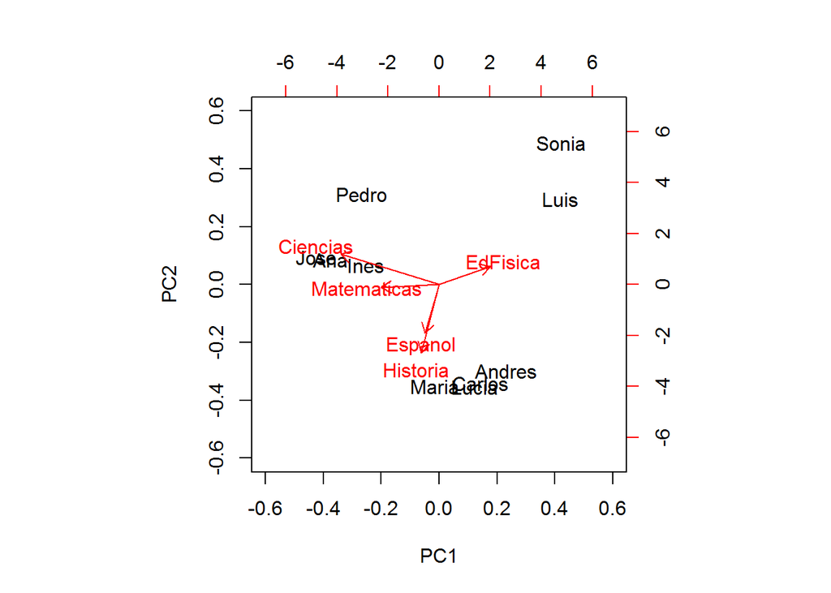

```r
biplot(modelo, ylim= (c(-.6,.6)), xlim= (c(-.6,.6)))
```

Example “Customer Support” Making the Principal Component Analysis (PCA)

```r
datos2 <- read.table("C:/Users/Usuario/Desktop/promidat/calibracion_y_seleccion/1/EjemploClientes.csv", header = TRUE, sep = ";", dec = ",",  row.names=1)
#calculo de las componentes principales
modelo2 <- prcomp(datos2)
modelo2
```

```
## Standard deviations:
##  [1] 7.4117643 2.8077928 2.3281022 1.8560000 1.7040880 1.5067604 1.1045369
##  [8] 0.9702921 0.8247988 0.7771967 0.6633479 0.4308039
##
## Rotation:
##                                 PC1          PC2          PC3         PC4
## Edad                    0.950101014  0.070202561 -0.263299263 -0.03678764
## Antiguedad              0.204961771  0.518532343  0.811648677  0.01402994
## Espacios.Parqueo        0.023553826  0.220381318 -0.148833334 -0.00108413
## Velocidad.Cajas        -0.073194839  0.110896795 -0.014842216  0.02452293
## Distribucion.Productos -0.156687314  0.445609895 -0.145585291  0.08848250
## Atencion.Empleados      0.012892195 -0.007911132 -0.010484490  0.02182760
## Calidad.Instalaciones  -0.013160009  0.253343164 -0.193899919  0.42402874
## Ubicacion              -0.008675596 -0.042987899 -0.069062798 -0.08852470
## Limpieza               -0.096258371  0.313832377 -0.173142896 -0.08783828
## Variedad.Productos     -0.068145762  0.312078669 -0.110370766  0.05395741
## Prestigio.Empresa      -0.094728350  0.441806448 -0.378992021 -0.13776352
## Calidad.Servicio       -0.039216244  0.097936247 -0.007829412 -0.87880540
##                                 PC5         PC6         PC7          PC8
## Edad                    0.001576954 -0.12057336  0.04564108 -0.013023628
## Antiguedad              0.054901047  0.04278761 -0.12122719 -0.009835162
## Espacios.Parqueo       -0.161282776  0.41138913  0.32287992  0.138032712
## Velocidad.Cajas         0.145209534 -0.35513356  0.10103346 -0.788790324
## Distribucion.Productos -0.458776167 -0.63242237  0.14368921  0.326539667
## Atencion.Empleados     -0.016777943  0.03784431 -0.05443340  0.063916768
## Calidad.Instalaciones  -0.487492832  0.35965028 -0.16179010 -0.403059590
## Ubicacion               0.075976016 -0.22312075 -0.46124439  0.107969110
## Limpieza                0.450674803 -0.04160764  0.53108310 -0.061229565
## Variedad.Productos      0.243879007  0.28746923  0.05085552  0.199113293
## Prestigio.Empresa       0.317003894  0.05867169 -0.56677507 -0.002416463
## Calidad.Servicio       -0.364184763  0.14119794  0.01897688 -0.173958557
##                                 PC9        PC10        PC11         PC12
## Edad                    0.005157417 -0.06523168  0.02456039 -0.004658619
## Antiguedad             -0.045733567  0.08815984 -0.02101634 -0.014191478
## Espacios.Parqueo        0.264165022  0.40124250 -0.59401748  0.162885434
## Velocidad.Cajas         0.261269264 -0.10864021 -0.26754853  0.224215575
## Distribucion.Productos  0.071554203 -0.05313854  0.03905588  0.026062213
## Atencion.Empleados     -0.312183071  0.06263473  0.17379019  0.926735339
## Calidad.Instalaciones  -0.355813160 -0.06545299  0.09785536 -0.148839104
## Ubicacion              -0.490761495 -0.06331496 -0.67630107 -0.057208168
## Limpieza               -0.548333503  0.16166902  0.09955713 -0.164906396
## Variedad.Productos      0.131633627 -0.81093982 -0.11344469  0.103448235
## Prestigio.Empresa       0.251222257  0.30976643  0.22128220 -0.003539608
## Calidad.Servicio       -0.093269857 -0.14289593  0.06388882 -0.010997470
```

The Biplot:

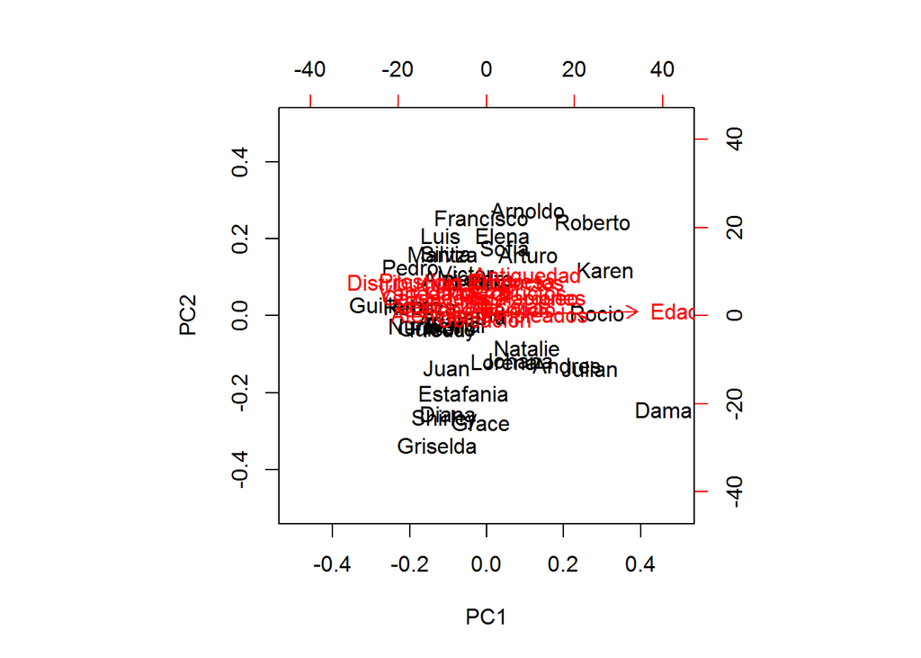

# Example of PCA on FactoMineR

Example “Students”

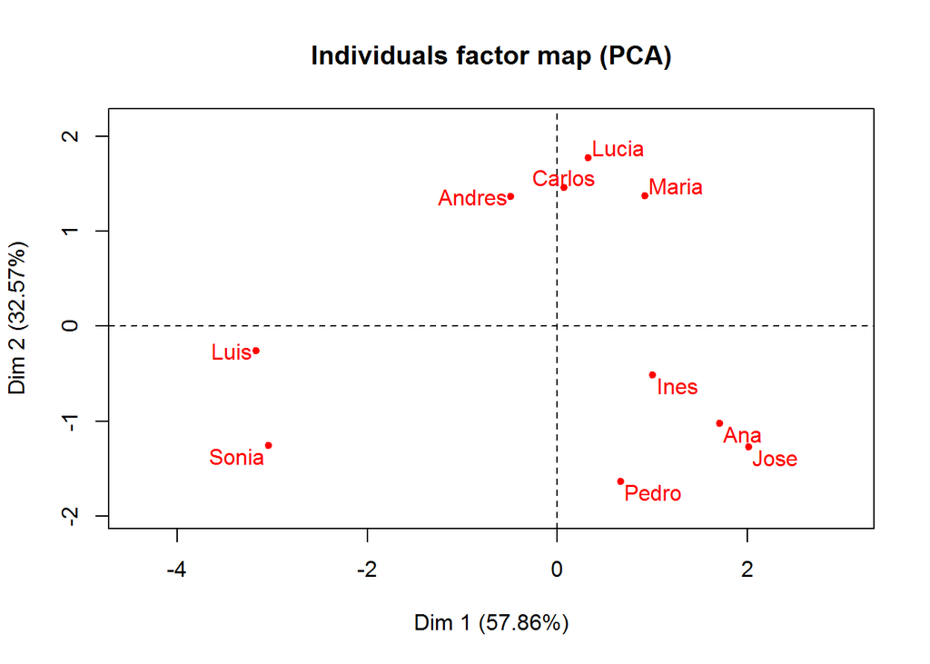

```r
suppressMessages(library(FactoMineR))
datos <- read.table("C:/Users/Usuario/Desktop/promidat/calibracion_y_seleccion/1/notas.csv", header = TRUE, sep = ";", dec = ",",  row.names=1)
#calculo de las componentes principales
modelo <- PCA(datos, scale.unit = TRUE, ncp=5, graph = FALSE)
plot(modelo, axes=c(1,2), choix="ind", col.ind="red", new.plot= TRUE)
```

# Ploting the Vars

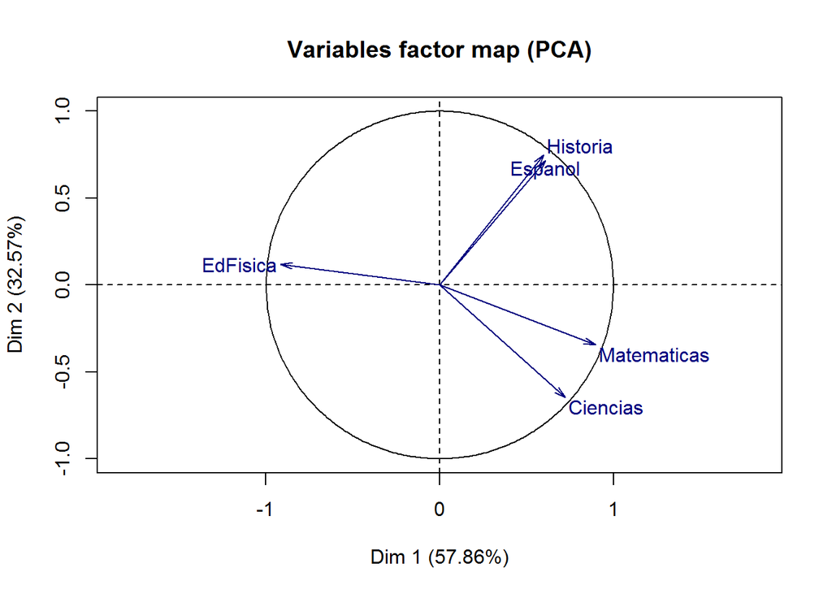

looking at the Individuals

```
## $coord
##              Dim.1      Dim.2       Dim.3       Dim.4        Dim.5
## Lucia   0.32306263  1.7725245  1.19880074 -0.05501532  0.003633384
## Pedro   0.66544057 -1.6387021  0.14547628 -0.02306468 -0.123377296
## Ines    1.00254705 -0.5156925  0.62888764  0.51644351  0.142875824
## Luis   -3.17209481 -0.2627820 -0.38196027  0.67777691 -0.062503554
## Andres -0.48886797  1.3654021 -0.83523570 -0.15579197  0.123367255
## Ana     1.70863322 -1.0217004 -0.12707707  0.06683295  0.025291503
## Carlos  0.06758577  1.4623364 -0.50624044 -0.11792847  0.013123980
## Jose    2.01185516 -1.2758646 -0.54215002 -0.19778670  0.017434170
## Sonia  -3.04203029 -1.2548807  0.44882861 -0.63999876  0.037884840
## Maria   0.92386867  1.3693593 -0.02932977 -0.07146746 -0.177730107
##
## $cos2
##              Dim.1       Dim.2       Dim.3        Dim.4        Dim.5
## Lucia  0.022270827 0.670420670 0.306659839 0.0006458478 2.816992e-06
## Pedro  0.139905502 0.848430539 0.006686527 0.0001680781 4.809354e-03
## Ines   0.514468899 0.136122895 0.202439714 0.1365196756 1.044882e-02
## Luis   0.936851990 0.006429392 0.013583605 0.0427712757 3.637375e-04
## Andres 0.084139511 0.656353715 0.245603703 0.0085448999 5.358172e-03
## Ana    0.732686110 0.261979570 0.004052795 0.0011209894 1.605349e-04
## Carlos 0.001892733 0.886081139 0.106192189 0.0057625700 7.136907e-05
## Jose   0.673612108 0.270910359 0.048916504 0.0065104446 5.058468e-05
## Sonia  0.808829929 0.137636943 0.017607237 0.0358004434 1.254472e-04
## Maria  0.308554271 0.677869212 0.000310977 0.0018464085 1.141913e-02
##
## $contrib
##              Dim.1      Dim.2       Dim.3       Dim.4       Dim.5
## Lucia   0.36073437 19.2910834 41.46392357  0.24684974  0.01484748
## Pedro   1.53049754 16.4881591  0.61060555  0.04338706 17.11987788
## Ines    3.47395038  1.6328779 11.41096846 21.75259335 22.95871968
## Luis   34.77814436  0.4239976  4.20932799 37.46613853  4.39379307
## Andres  0.82603273 11.4470414 20.12771563  1.97950024 17.11709152
## Ana    10.09047896  6.4094282  0.46591936  0.36428947  0.71941493
## Carlos  0.01578791 13.1300601  7.39418080  1.13423412  0.19371414
## Jose   13.98967133  9.9949649  8.48038057  3.19050613  0.34184774
## Sonia  31.98461714  9.6688984  5.81215853 33.40593699  1.61421395
## Maria   2.95008527 11.5134890  0.02481953  0.41656436 35.52647960
##
## $dist
##    Lucia    Pedro     Ines     Luis   Andres      Ana   Carlos     Jose
## 2.164804 1.779065 1.397736 3.277258 1.685356 1.996135 1.553497 2.451273
##    Sonia    Maria
## 3.382478 1.663200
```

```
## $coord
##                  Dim.1      Dim.2       Dim.3       Dim.4       Dim.5
## Matematicas  0.8957980 -0.3452036  0.25797931 -0.09146818  0.05882803
## Ciencias     0.7227976 -0.6483946  0.02384033  0.23587773 -0.03068234
## Espanol      0.6108931  0.7173206  0.33102532 -0.02454152 -0.04561456
## Historia     0.5999227  0.7484701 -0.23206345  0.15639747  0.03964443
## EdFisica    -0.9139265  0.1196373  0.34065108  0.18315368  0.02892890
##
## $cor
##                  Dim.1      Dim.2       Dim.3       Dim.4       Dim.5
## Matematicas  0.8957980 -0.3452036  0.25797931 -0.09146818  0.05882803
## Ciencias     0.7227976 -0.6483946  0.02384033  0.23587773 -0.03068234
## Espanol      0.6108931  0.7173206  0.33102532 -0.02454152 -0.04561456
## Historia     0.5999227  0.7484701 -0.23206345  0.15639747  0.03964443
## EdFisica    -0.9139265  0.1196373  0.34065108  0.18315368  0.02892890
##
## $cos2
##                 Dim.1      Dim.2        Dim.3        Dim.4        Dim.5
## Matematicas 0.8024540 0.11916550 0.0665533242 0.0083664287 0.0034607374
## Ciencias    0.5224364 0.42041555 0.0005683612 0.0556383052 0.0009414059
## Espanol     0.3731904 0.51454884 0.1095777630 0.0006022863 0.0020806881
## Historia    0.3599073 0.56020745 0.0538534429 0.0244601695 0.0015716811
## EdFisica    0.8352616 0.01431309 0.1160431572 0.0335452699 0.0008368811
##
## $contrib
##                Dim.1      Dim.2      Dim.3      Dim.4    Dim.5
## Matematicas 27.73539  7.3168250 19.2019858  6.8234735 38.92233
## Ciencias    18.05708 25.8137375  0.1639838 45.3773665 10.58783
## Espanol     12.89866 31.5935718 31.6154103  0.4912113 23.40115
## Historia    12.43955 34.3970346 15.5378121 19.9491712 17.67643
## EdFisica    28.86932  0.8788311 33.4808079 27.3587774  9.41226
```

# Poorly represented individuals

```
##    Lucia    Pedro     Ines     Luis   Andres      Ana   Carlos     Jose
## 69.26915 98.83360 65.05918 94.32814 74.04932 99.46657 88.79739 94.45225
##    Sonia    Maria
## 94.64669 98.64235
```

# Example “Customer Support”

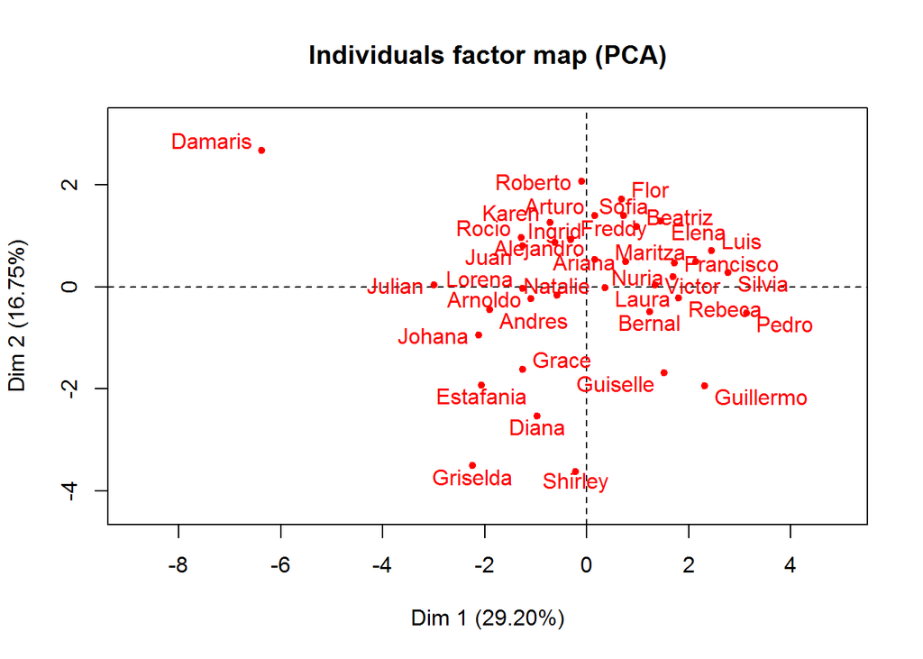

```r
suppressMessages(library(FactoMineR))
datos <- read.table("C:/Users/Usuario/Desktop/promidat/calibracion_y_seleccion/1/EjemploClientes.csv", header = TRUE, sep = ";", dec = ",",  row.names=1)
#calculo de las componentes principales
modelo2 <- PCA(datos, scale.unit = TRUE, ncp=5, graph = FALSE)
plot(modelo2, axes=c(1,2), choix="ind", col.ind="red", new.plot= TRUE)
```

Plotting

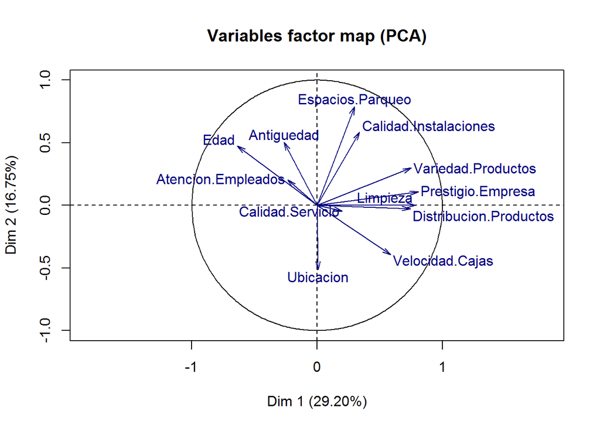

Results of Individuals

```
## $coord
##                   Dim.1        Dim.2       Dim.3       Dim.4       Dim.5
##  Ariana      0.76724718  0.497238477  0.57191530  0.16142452 -1.65579060
##  Guiselle    1.51879315 -1.686836572  0.98779173  0.17221105  0.55005406
##  Francisco   1.71443791  0.475624696 -1.51566662  2.28218057  0.20056414
##  Griselda   -2.23251816 -3.508069268  0.66359311 -0.52495711 -1.22332313
##  Damaris    -6.36720222  2.675537005  0.87732588 -0.10100213 -0.70361785
##  Johana     -2.11556163 -0.941570177  0.65407189  0.81760454 -0.82345506
##  Bernal      1.24128043 -0.487346646 -0.17795113  0.54891028 -0.83682569
##  Freddy     -0.31190034  0.929512482 -1.03796398 -1.08541018 -0.80334661
##  Estafania  -2.06945065 -1.927821933  0.45295770  1.26188336 -0.44095495
##  Laura       0.36040824 -0.009833987  1.95016527 -0.20502540 -1.67137252
##  Arnoldo    -1.08908493 -0.227199651 -0.28174266  0.68345697  3.12540149
##  Beatriz     0.97322489  1.185905461 -2.64768083 -0.08470250 -0.47254185
##  Rebeca      1.79978893 -0.218346489  1.24199203 -0.99179274 -0.80924517
##  Sofia       0.71764078  1.394132648  1.22044456 -0.99825080  1.05944825
##  Ingrid     -0.62268210  0.876312869  0.57460175 -0.88355299  0.05891503
##  Rocio      -1.28742021  0.961862747 -0.99864085 -0.08528009  0.09834110
##  Karen      -0.72088316  1.266962949 -0.03703915  0.68595062  0.82752988
##  Luis        2.44934451  0.713298931 -0.51178881  2.22171772 -0.81924899
##  Pedro       3.12777300 -0.518380517  1.43861683 -0.14252813  0.20545085
##  Lorena     -1.25140018 -0.026560512 -0.80288968  0.06599784  0.11400902
##  Elena       1.45202778  1.293706091 -0.59742235  0.73368519  0.51453155
##  Julian     -2.99795876  0.044846544 -0.19287844 -1.46956882  1.33984599
##  Natalie    -0.58660926 -0.169452701  1.67954011  1.52326321  1.10659730
##  Shirley    -0.22314892 -3.626845518 -3.06763263 -1.06150839  0.18137029
##  Andres     -1.90361516 -0.443369910 -0.37240288  1.35343769 -0.22036035
##  Alejandro   0.15773821  0.532747746 -0.92923360 -1.44613151  0.10961940
##  Grace      -1.25857116 -1.610887903  0.82633681  0.85314555  0.12250664
##  Nuria       1.69867242  0.198294935 -0.76236829 -1.86754877 -0.52001288
##  Flor        0.67628345  1.721238782  0.62011051 -2.17795649 -1.03602407
##  Roberto    -0.09565206  2.077048397 -0.18169306 -0.69588726  1.97297172
##  Victor      1.33934648  0.042637391  0.20307881  0.63905320  0.14885848
##  Arturo      0.15570306  1.397385225 -0.90109844  0.69448333 -0.55158109
##  Maritza     2.13410549  0.495758603  0.76679121  0.58927061  0.81276537
##  Diana      -0.97432560 -2.537432968  0.31974219 -0.94316986  1.36125191
##  Juan       -1.25463858  0.810176344 -0.88635053  0.71380678 -1.74172731
##  Guillermo   2.31102047 -1.934685534 -0.41837852 -0.77341274 -0.05249839
##  Silvia      2.76778673  0.284411963  1.27174677 -0.46379714  0.47189404
##
```

[output cut: 156 more lines]

```
## $dist
##     Ariana    Guiselle   Francisco    Griselda     Damaris      Johana
##    2.415393    3.020998    3.764258    4.910801    7.228356    3.286231
##     Bernal      Freddy   Estafania       Laura     Arnoldo     Beatriz
##    2.273092    2.969138    3.552385    3.438301    4.312621    3.428493
##     Rebeca       Sofia      Ingrid       Rocio       Karen        Luis
##    2.890213    2.731428    2.370810    3.103412    2.360946    3.931753
##      Pedro      Lorena       Elena      Julian     Natalie     Shirley
##    3.649187    2.140118    2.519131    3.755657    3.848640    5.261842
##     Andres   Alejandro       Grace       Nuria        Flor     Roberto
##    2.846046    2.306150    3.073499    3.134755    3.258360    3.287001
##     Victor      Arturo     Maritza       Diana        Juan   Guillermo
##    2.303553    2.730945    2.836700    3.731150    3.800286    3.308827
##     Silvia
##    3.427352
```

# put away the Poorly represented individuals

```
##     Ariana    Guiselle   Francisco    Griselda     Damaris      Johana
##   14.328015   56.453084   22.340133   71.698082   91.292941   49.652734
##     Bernal      Freddy   Estafania       Laura     Arnoldo     Beatriz
##   34.416536   10.904032   63.387326    1.099575    6.654904   20.022333
##     Rebeca       Sofia      Ingrid       Rocio       Karen        Luis
##   39.348565   32.954200   20.560584   26.815353   38.120604   42.099868
##      Pedro      Lorena       Elena      Julian     Natalie     Shirley
##   75.482549   34.206822   59.597329   63.734795    2.517039   47.689567
##     Andres   Alejandro       Grace       Nuria        Flor     Roberto
##   47.164655    5.804482   44.238669   29.763926   32.212962   40.014149
##     Victor      Arturo     Maritza       Diana        Juan   Guillermo
##   33.839927   26.507278   59.652830   53.068172   15.444379   82.969907
##     Silvia
##   65.903655
```

Plotting without the Poorly represented individuals

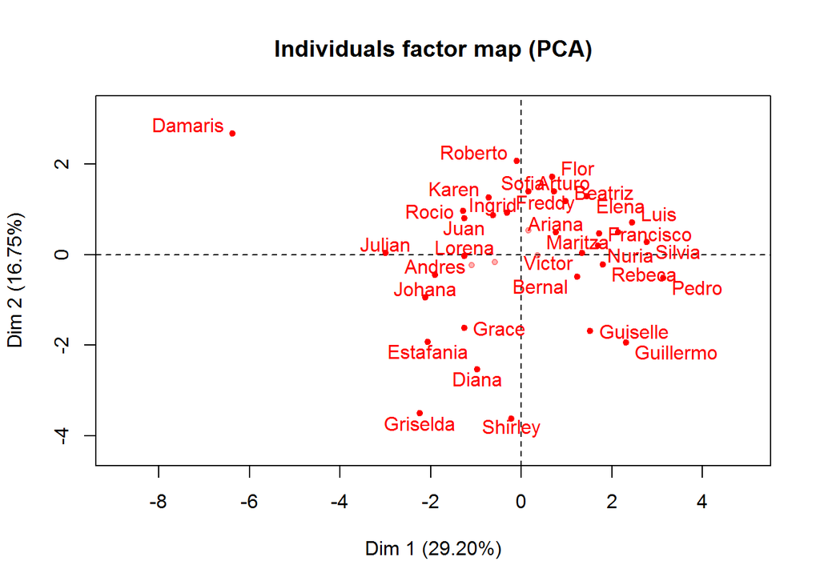

```r
#Se selecciona de los datos los individuos (ind) cuyos cos2 sean mayores a 0.1
plot(modelo2, axes = c(1,2), choix = "ind", col.ind = "red", new.plot = TRUE, select = "cos2 0.1")
```

## Example Clustering Hierarchy

Students

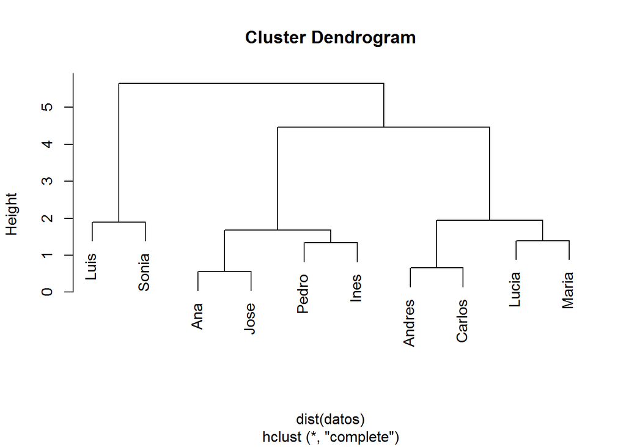

```r
datos <- read.table("C:/Users/Usuario/Desktop/promidat/calibracion_y_seleccion/1/notas.csv", header = TRUE, sep = ";", dec = ",",  row.names=1)
#calculo de los cluster usando salto maximo
modelo <- hclust(dist(datos), method = "complete")

#Graficamos
plot(modelo)
```

Plotting with 3 clusters

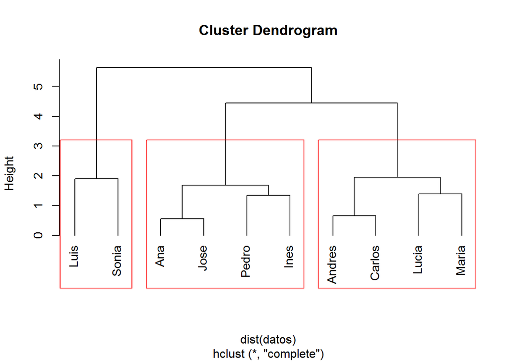

```r
plot( modelo, hang = -1)
rect.hclust(modelo, k =3, border = "red")
```

Examnple “Students”, HC method: single

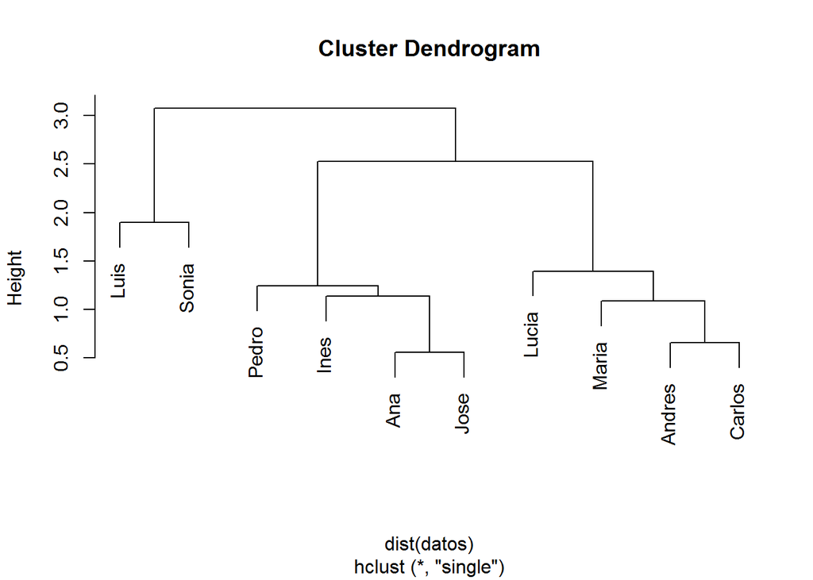

```r
datos <- read.table("C:/Users/Usuario/Desktop/promidat/calibracion_y_seleccion/1/notas.csv", header = TRUE, sep = ";", dec = ",",  row.names=1)
#calculo de los cluster usando salto minimo
modelo <- hclust(dist(datos), method = "single")

#Graficamos
plot(modelo)
```

Plotting with 3 Clusters

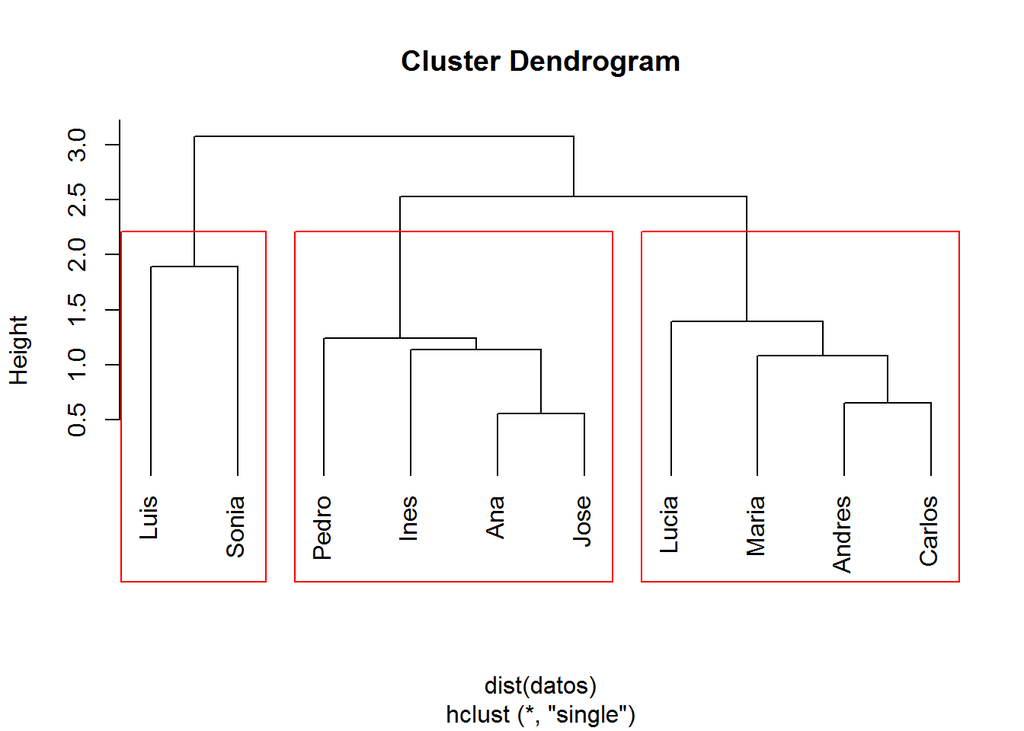

```r
plot( modelo, hang = -1)
rect.hclust(modelo, k =3, border = "red")
```

Examnple “Students”, HC method: average

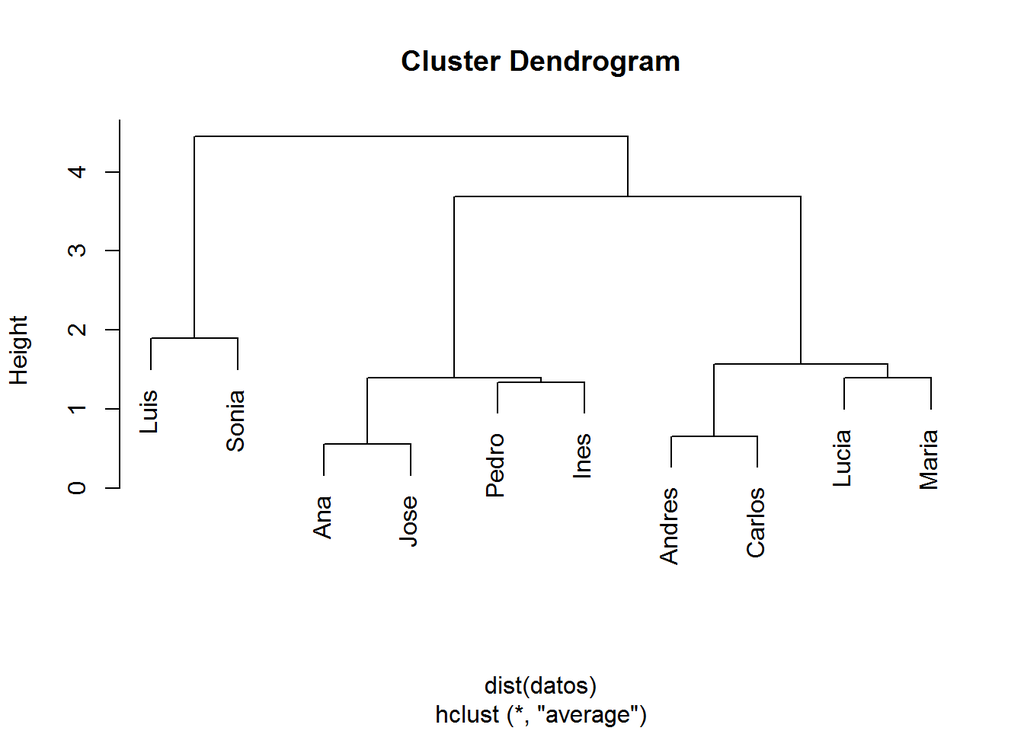

```r
datos <- read.table("C:/Users/Usuario/Desktop/promidat/calibracion_y_seleccion/1/notas.csv", header = TRUE, sep = ";", dec = ",",  row.names=1)
#calculo de los cluster usando salto maximo
modelo <- hclust(dist(datos), method = "average")

#Graficamos
plot(modelo)
```

Plotting with 3 clusters

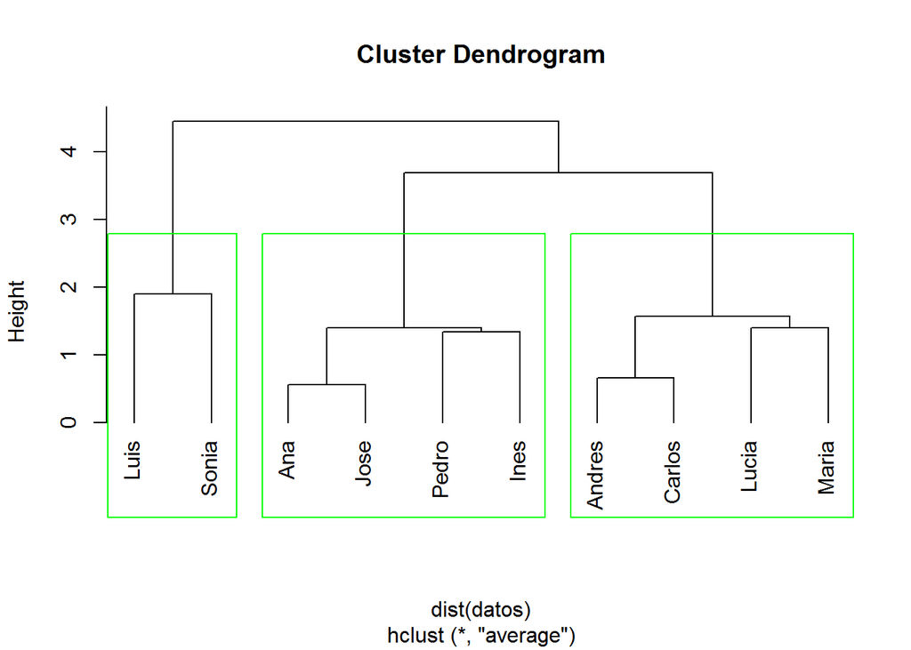

```r
plot( modelo, hang = -1)
rect.hclust(modelo, k =3, border = "green")
```

# Saving assigning cluster and individuals

```r
#cortamos el arbol con k cluesteres
grupo <- cutree(modelo, k=3)

#lo agregamos a la tabla
ndatos<- cbind(datos, grupo)
ndatos
```

```
##        Matematicas Ciencias Espanol Historia EdFisica grupo
## Lucia          7.0      6.5     9.2      8.6      8.0     1
## Pedro          7.5      9.4     7.3      7.0      7.0     2
## Ines           7.6      9.2     8.0      8.0      7.5     2
## Luis           5.0      6.5     6.5      7.0      9.0     3
## Andres         6.0      6.0     7.8      8.9      7.3     1
## Ana            7.8      9.6     7.7      8.0      6.5     2
## Carlos         6.3      6.4     8.2      9.0      7.2     1
## Jose           7.9      9.7     7.5      8.0      6.0     2
## Sonia          6.0      6.0     6.5      5.5      8.7     3
## Maria          6.8      7.2     8.7      9.0      7.0     1
```

# Save the file as .csv

```r
write.csv(ndatos, "notas-grupos.csv")
```

# Making Clustering over PCA

example “Students”

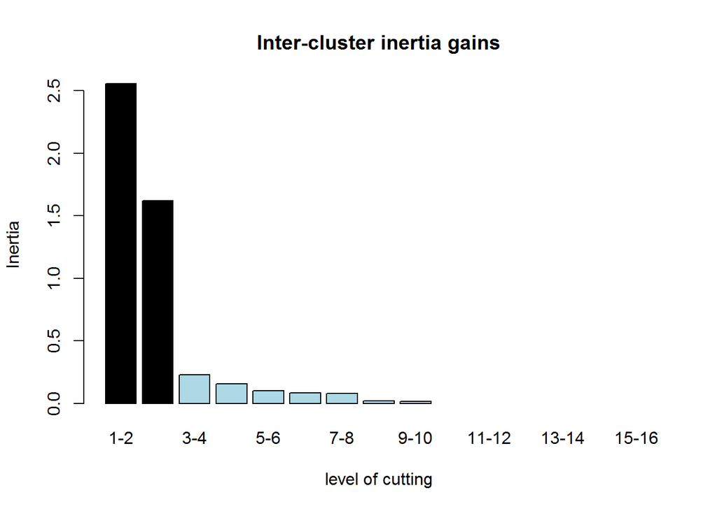

```r
suppressMessages(library(FactoMineR))
datos <- read.table("C:/Users/Usuario/Desktop/promidat/calibracion_y_seleccion/1/notas.csv", header = TRUE, sep = ";", dec = ",",  row.names=1)
#calculo de las componentes principales
modelo <- PCA(datos, scale.unit = TRUE, ncp=3, graph = FALSE)
modelo.hcpc <- HCPC(modelo, nb.clust = -1, consol = TRUE, min = 3, max=3, graph = FALSE)

plot.HCPC(modelo.hcpc, choice = "bar")
```

plotting to see the clusters

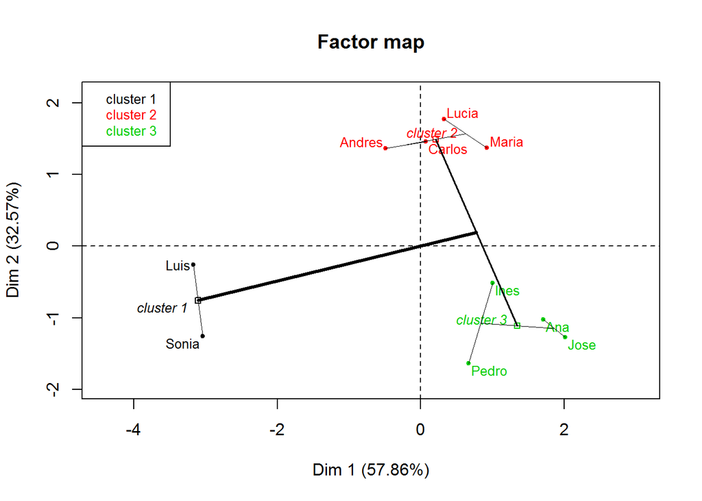

```r
plot.HCPC(modelo.hcpc, choice = "map")
```

3d-Plotting

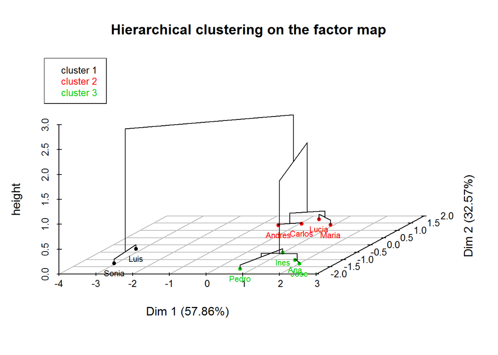

```r
plot(modelo.hcpc)
```

# Analysis

Example students

```r
library(rattle)
datos <- read.table("C:/Users/Usuario/Desktop/promidat/calibracion_y_seleccion/1/notas.csv", header = TRUE, sep = ";", dec = ",",  row.names=1)
#calculo de los cluster usando salto promedio
modelo <- hclust(dist(datos), method = "average")
centros <- centers.hclust(datos, modelo, nclust = 3, use.median = FALSE  )
centros
```

```
##      Matematicas Ciencias Espanol Historia EdFisica
## [1,]       6.525    6.525   8.475    8.875    7.375
## [2,]       7.700    9.475   7.625    7.750    6.750
## [3,]       5.500    6.250   6.500    6.250    8.850
```

Plotting

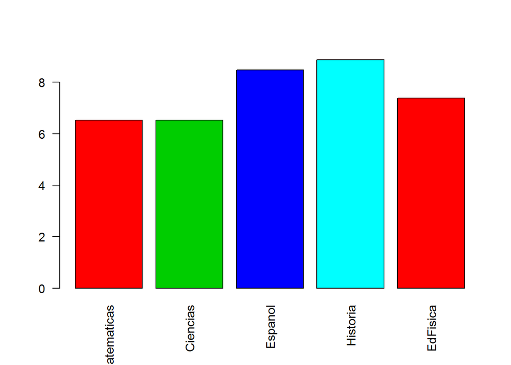

```r
rownames(centros)<- c("cluster1", "cluster2", "cluster3")
barplot(centros[1,], las =2, col=c(2,3,4,5))
```

```r
centros
```

```
##          Matematicas Ciencias Espanol Historia EdFisica
## cluster1       6.525    6.525   8.475    8.875    7.375
## cluster2       7.700    9.475   7.625    7.750    6.750
## cluster3       5.500    6.250   6.500    6.250    8.850
```

Making the barplot on every cluster

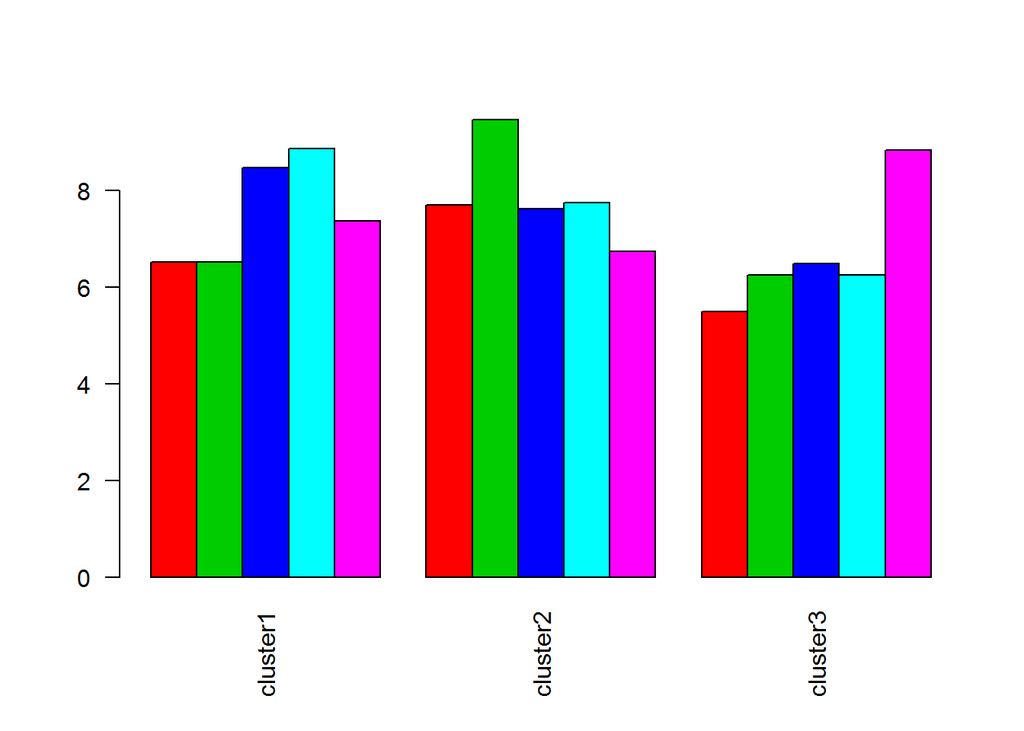

```r
barplot(t(centros), beside = TRUE,  las =2, col=c(2,3,4,5,6))
```

# another Charts i,e: radarChart

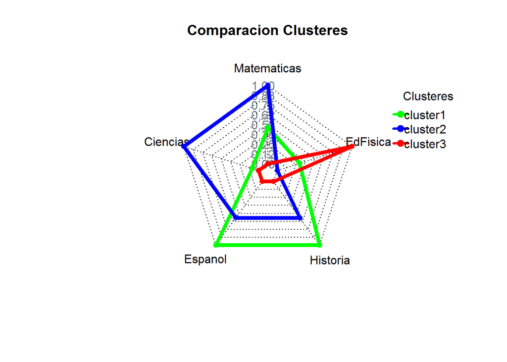

```r
#cargamos paquete para usar radarchat
library(fmsb)
centros<- as.data.frame(centros)
maxi <- apply(centros, 2, max)
mini <- apply(centros, 2, min)
centros <- rbind(mini, centros)
centros <- rbind(maxi, centros)

radarchart(centros, maxmin = TRUE, axistype = 4, axislabcol = "slategray4",  centerzero = FALSE, seg=8, cglcol = "gray4", pcol=c("green","blue", "red"), plty = 1, plwd = 5, title="Comparacion Clusteres")
legenda <- legend(1.5,1, legend= c("cluster1", "cluster2", "cluster3"), seg.len=-1.4, title = "Clusteres", pch = 21, bty= "n", lwd = 3, y.intersp = 1, horiz = FALSE, col = c("green","blue", "red"))
```

## Customer Support Example

```r
suppressMessages(library(FactoMineR))
datos <- read.table("C:/Users/Usuario/Desktop/promidat/calibracion_y_seleccion/1/EjemploClientes.csv", header = TRUE, sep = ";", dec = ",",  row.names=1)

#Escalamos los datos de Edad
datos$Edad<- datos$Edad/10
#Cluatering con el metodo ward
modelo2 <-  hclust(dist(datos), method = "ward")
```

```
## The "ward" method has been renamed to "ward.D"; note new "ward.D2"
```

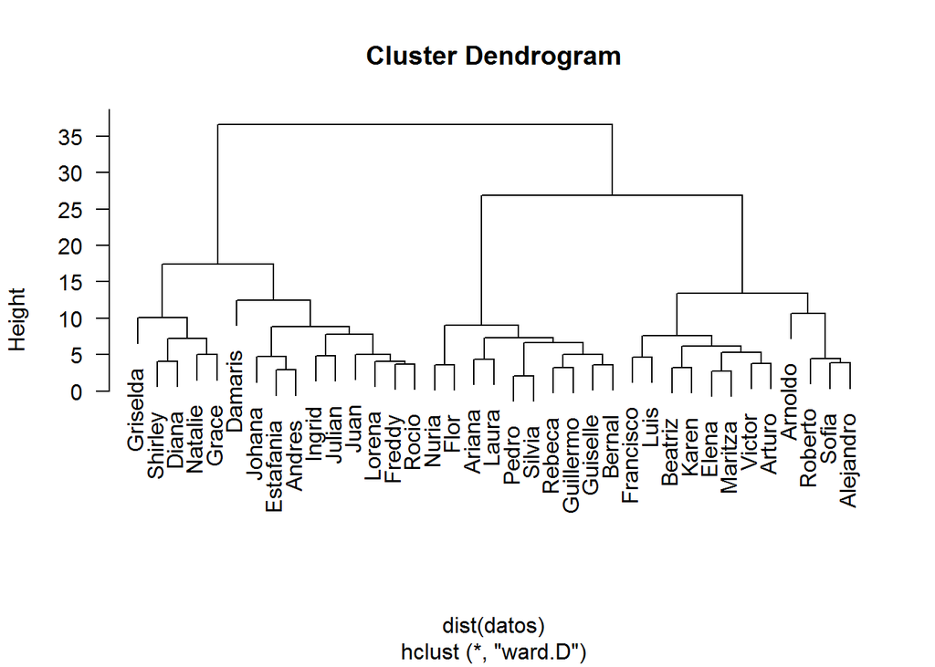

```r
plot(modelo2, las=1)
```

Caluclate the center of the clusters

```r
centros <- centers.hclust(datos, modelo2, nclust = 3, use.median = FALSE  )
centros
```

```
##          Edad Antiguedad Espacios.Parqueo Velocidad.Cajas
## [1,] 2.360000   0.600000         6.220000            8.34
## [2,] 3.066667   5.833333         6.850000            8.10
## [3,] 3.080000   3.000000         5.466667            7.44
##      Distribucion.Productos Atencion.Empleados Calidad.Instalaciones
## [1,]               8.120000           9.700000              4.700000
## [2,]               7.600000           9.508333              3.500000
## [3,]               4.626667           9.713333              2.406667
##      Ubicacion Limpieza Variedad.Productos Prestigio.Empresa
## [1,]  9.160000 7.360000           7.440000          8.520000
## [2,]  8.833333 7.450000           7.466667          7.933333
## [3,]  9.026667 5.626667           5.960000          5.426667
##      Calidad.Servicio
## [1,]            5.070
## [2,]            5.325
## [3,]            4.960
```

Plotting

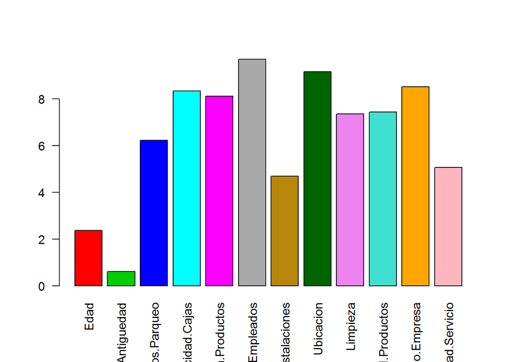

```r
rownames(centros)<- c("cluster1", "cluster2", "cluster3")
barplot(centros[1,], las =2, col=c(2:13))
```

```r
centros
```

```
##              Edad Antiguedad Espacios.Parqueo Velocidad.Cajas
## cluster1 2.360000   0.600000         6.220000            8.34
## cluster2 3.066667   5.833333         6.850000            8.10
## cluster3 3.080000   3.000000         5.466667            7.44
##          Distribucion.Productos Atencion.Empleados Calidad.Instalaciones
## cluster1               8.120000           9.700000              4.700000
## cluster2               7.600000           9.508333              3.500000
## cluster3               4.626667           9.713333              2.406667
##          Ubicacion Limpieza Variedad.Productos Prestigio.Empresa
## cluster1  9.160000 7.360000           7.440000          8.520000
## cluster2  8.833333 7.450000           7.466667          7.933333
## cluster3  9.026667 5.626667           5.960000          5.426667
##          Calidad.Servicio
## cluster1            5.070
## cluster2            5.325
## cluster3            4.960
```

Group by cluster and Plotting

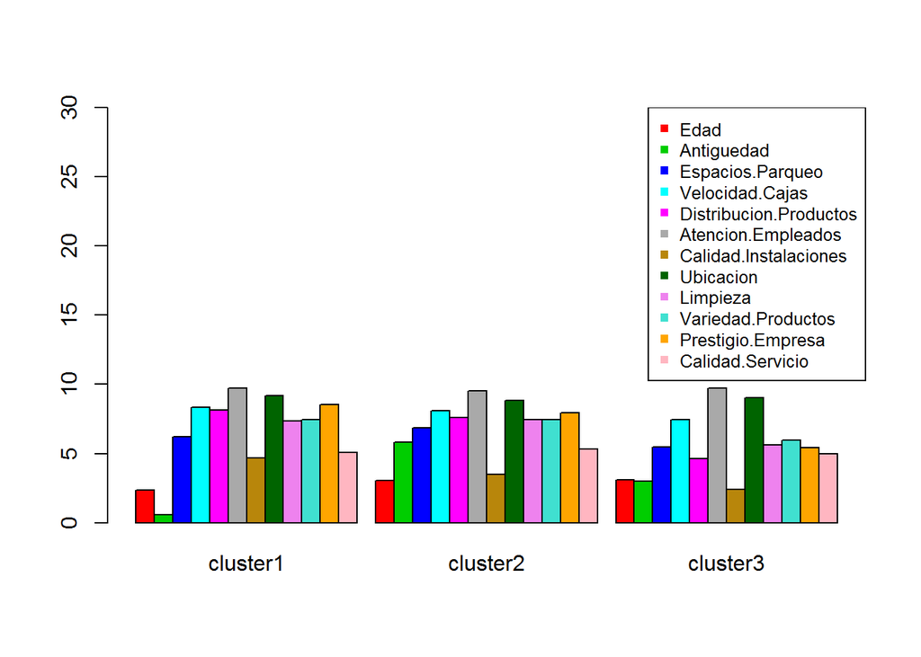

```r
barplot(t(centros), beside = TRUE, col=c(2:13), ylim = c(0,30))
legend("topright", legend=colnames(datos),
       col=c(2:13), pch=15, cex=0.8)
```

# RadarChart

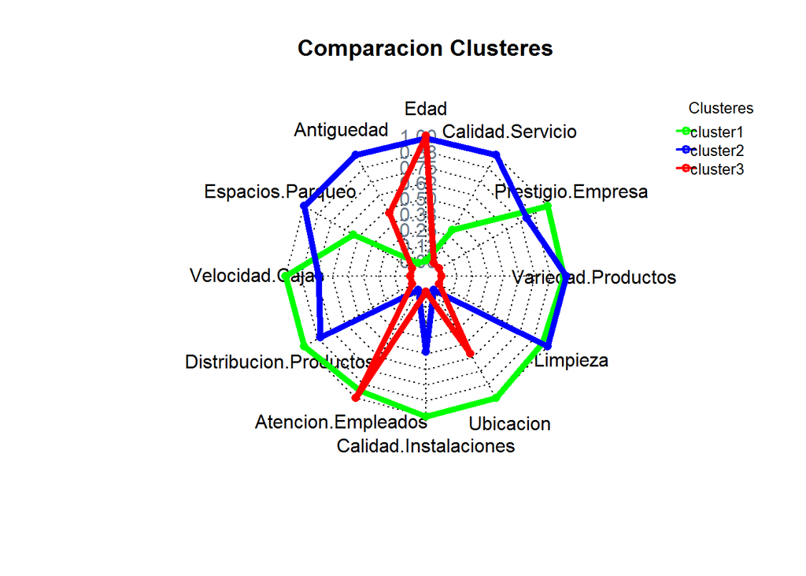

```r
#cargamos paquete para usar radarchat
library(fmsb)
centros<- as.data.frame(centros)
maxi <- apply(centros, 2, max)
mini <- apply(centros, 2, min)
centros <- rbind(mini, centros)
centros <- rbind(maxi, centros)

radarchart(centros, maxmin = TRUE, axistype = 4, axislabcol = "slategray4",  centerzero = FALSE, seg=8, cglcol = "gray4", pcol=c("green","blue", "red"), plty = 1, plwd = 5, title="Comparacion Clusteres")
legenda <- legend("topright", legend= c("cluster1", "cluster2", "cluster3"), seg.len=-1.4, title = "Clusteres", pch = 21, bty= "n", lwd = 2, y.intersp = 1, horiz = FALSE, col = c("green","blue", "red"),cex=0.8 )
```

# K-means example

```r
suppressMessages(library(FactoMineR))
#Cargamos los datos
datos <- read.table("C:/Users/Usuario/Desktop/promidat/calibracion_y_seleccion/1/Ej1kmeans.csv", header = FALSE, sep = ";")

datos
```

```
##               V1           V2
## 1   -0.350856890  0.334849453
## 2    0.431246262 -0.231926178
## 3   -0.234252742 -0.137232265
## 4   -0.294221022 -0.481727669
## 5   -0.151274199  0.363785185
## 6    0.324703737 -0.164754888
## 7   -0.207368187  0.531442950
## 8    0.023724256 -0.110664074
## 9    0.283070987  0.003797649
## 10  -0.118937613  0.326092211
## 11   0.167657628  0.564778878
## 12   0.059513418  0.286249235
## 13   0.243742378  0.267528878
## 14   0.145270952 -0.314866668
```

[output cut: 86 more lines]

Plotting

```r
#agrupamos por el metodo kmeans
grupos<- kmeans(datos, 2, iter.max = 100)
grupos
```

```
## K-means clustering with 2 clusters of sizes 49, 51
##
## Cluster means:
##           V1         V2
## 1 0.99128291 1.07898833
## 2 0.02169424 0.08865999
##
## Clustering vector:
##   [1] 2 2 2 2 2 2 2 2 2 2 2 2 2 2 2 2 2 2 2 2 2 2 2 2 2 2 2 2 2 2 2 2 2 2 2
##  [36] 2 2 2 2 2 2 2 2 2 2 2 2 2 2 2 1 1 1 1 1 1 1 2 1 1 1 1 1 1 1 1 1 1 1 1
##  [71] 1 1 1 1 1 1 1 1 1 1 1 1 1 1 1 1 1 1 1 1 1 1 1 1 1 1 1 1 1 1
##
## Within cluster sum of squares by cluster:
## [1] 9.397754 7.489019
##  (between_SS / total_SS =  74.0 %)
##
## Available components:
##
## [1] "cluster"      "centers"      "totss"        "withinss"
## [5] "tot.withinss" "betweenss"    "size"         "iter"
## [9] "ifault"
```

Seeing the Group of each individual

```r
#el cluster de Cada individuo
grupos$cluster
```

```
##   [1] 2 2 2 2 2 2 2 2 2 2 2 2 2 2 2 2 2 2 2 2 2 2 2 2 2 2 2 2 2 2 2 2 2 2 2
##  [36] 2 2 2 2 2 2 2 2 2 2 2 2 2 2 2 1 1 1 1 1 1 1 2 1 1 1 1 1 1 1 1 1 1 1 1
##  [71] 1 1 1 1 1 1 1 1 1 1 1 1 1 1 1 1 1 1 1 1 1 1 1 1 1 1 1 1 1 1
```

```r
#el centro de gravedad
grupos$centers
```

```
##           V1         V2
## 1 0.99128291 1.07898833
## 2 0.02169424 0.08865999
```

```r
#Inercia total
grupos$totss
```

```
## [1] 64.88887
```

```r
#Inercia intra-clases
grupos$withinss
```

```
## [1] 9.397754 7.489019
```

```r
#Tama?o de las clases
grupos$size
```

```
## [1] 49 51
```

Adding Color to the Chart

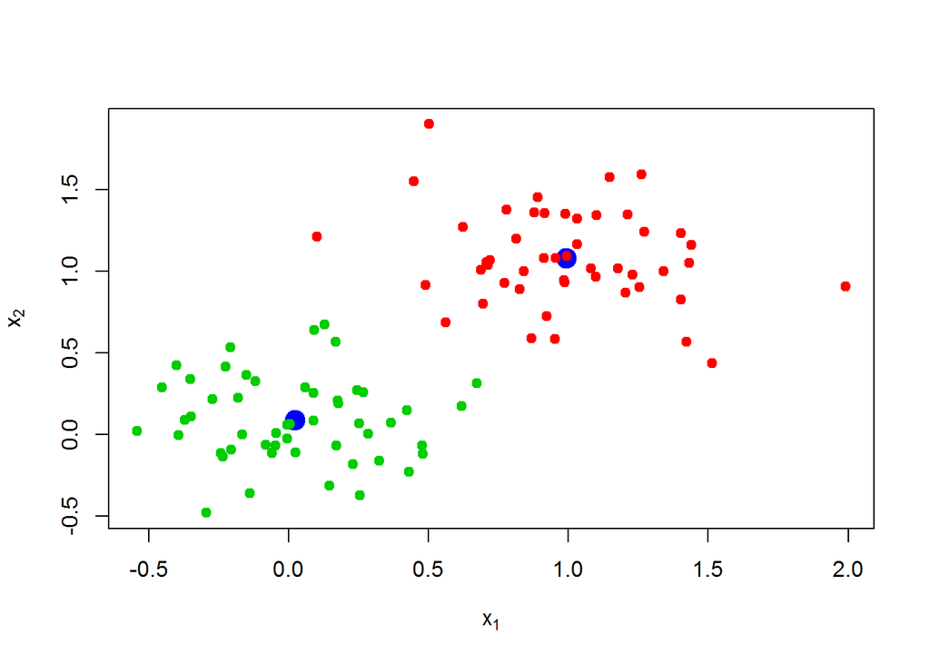

```r
plot(datos, pch=19, xlab=expression(x[1]), ylab= expression(x[2]))

points(grupos$centers, pch=19, col="blue", cex=2)
points(datos, col=grupos$cluster +1, pch=19)
```

Barplot on gravity center

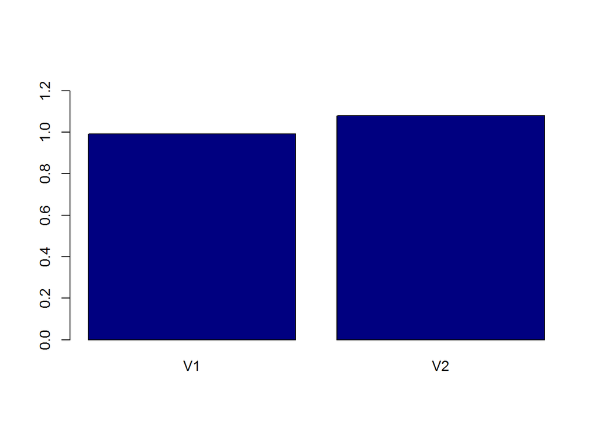

```r
#Tama?o de las clases
barplot(grupos$centers[1,], col = "navy", ylim=c(0,1.3))
```

# k-mean Customer Support Example

```r
suppressMessages(library(FactoMineR))
datos <- read.table("C:/Users/Usuario/Desktop/promidat/calibracion_y_seleccion/1/EjemploClientes.csv", header = TRUE, sep = ";", dec = ",",  row.names=1)

#Escalamos los datos de Edad
datos$Edad<- datos$Edad/10
```

Plotting

```r
#agrupamos por el metodo kmeans
grupos<- kmeans(datos, 3, iter.max = 1000)
grupos
```

```
## K-means clustering with 3 clusters of sizes 15, 9, 13
##
## Cluster means:
##       Edad Antiguedad Espacios.Parqueo Velocidad.Cajas
## 1 3.320000  5.3333333         6.053333        7.666667
## 2 2.722222  4.0000000         6.955556        8.155556
## 3 2.484615  0.3846154         5.615385        7.984615
##   Distribucion.Productos Atencion.Empleados Calidad.Instalaciones
## 1               5.160000           9.713333              3.400000
## 2               8.288889           9.600000              3.811111
## 3               6.907692           9.592308              3.061538
##   Ubicacion Limpieza Variedad.Productos Prestigio.Empresa Calidad.Servicio
## 1  8.653333 5.746667           6.173333          5.826667         4.960000
## 2  9.177778 8.000000           8.222222          8.622222         6.033333
## 3  9.276923 6.861538           6.676923          7.446154         4.638462
##
## Clustering vector:
##     Ariana    Guiselle   Francisco    Griselda     Damaris      Johana
##           3           3           2           3           1           1
##     Bernal      Freddy   Estafania       Laura     Arnoldo     Beatriz
##           3           1           1           3           1           1
##     Rebeca       Sofia      Ingrid       Rocio       Karen        Luis
##           3           2           1           1           1           2
##      Pedro      Lorena       Elena      Julian     Natalie     Shirley
##           2           1           2           1           3           3
##     Andres   Alejandro       Grace       Nuria        Flor     Roberto
##           1           1           3           3           3           1
##     Victor      Arturo     Maritza       Diana        Juan   Guillermo
##           2           2           2           3           1           3
##     Silvia
##           2
##
## Within cluster sum of squares by cluster:
## [1] 354.8707 116.7844 289.8569
##  (between_SS / total_SS =  32.6 %)
##
## Available components:
##
## [1] "cluster"      "centers"      "totss"        "withinss"
## [5] "tot.withinss" "betweenss"    "size"         "iter"
## [9] "ifault"
```

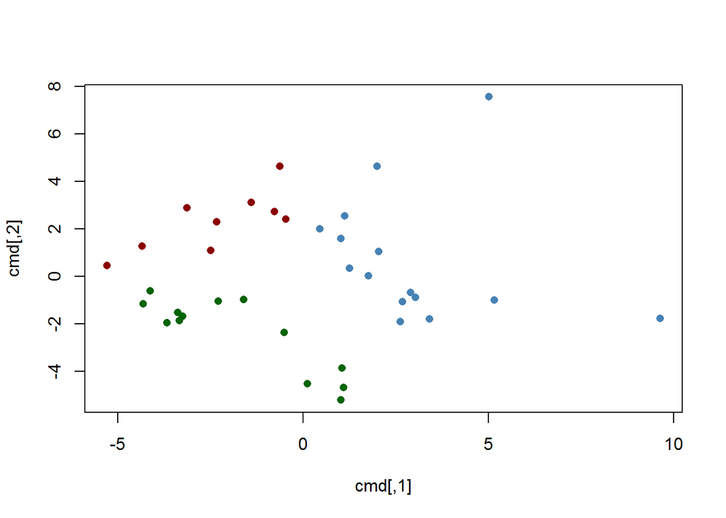

```r
# distance matrix
datos_dist <- dist(datos)

# Multidimensional scaling
cmd <- cmdscale(datos_dist)

# plot MDS, with colors by groups from kmeans
groups <- levels(factor(grupos$cluster))
plot(cmd, type = "n")
cols <- c("steelblue", "darkred", "darkgreen")
for(i in seq_along(groups)){
  points(cmd[factor(grupos$cluster) == groups[i], ], col = cols[i], pch = 16)
}
```

Checking some values, like groups, inertial center, size, etc

```r
#el cluster de Cada individuo
grupos$cluster
```

```
##     Ariana    Guiselle   Francisco    Griselda     Damaris      Johana
##           3           3           2           3           1           1
##     Bernal      Freddy   Estafania       Laura     Arnoldo     Beatriz
##           3           1           1           3           1           1
##     Rebeca       Sofia      Ingrid       Rocio       Karen        Luis
##           3           2           1           1           1           2
##      Pedro      Lorena       Elena      Julian     Natalie     Shirley
##           2           1           2           1           3           3
##     Andres   Alejandro       Grace       Nuria        Flor     Roberto
##           1           1           3           3           3           1
##     Victor      Arturo     Maritza       Diana        Juan   Guillermo
##           2           2           2           3           1           3
##     Silvia
##           2
```

```r
#el centro de gravedad
grupos$centers
```

```
##       Edad Antiguedad Espacios.Parqueo Velocidad.Cajas
## 1 3.320000  5.3333333         6.053333        7.666667
## 2 2.722222  4.0000000         6.955556        8.155556
## 3 2.484615  0.3846154         5.615385        7.984615
##   Distribucion.Productos Atencion.Empleados Calidad.Instalaciones
## 1               5.160000           9.713333              3.400000
## 2               8.288889           9.600000              3.811111
## 3               6.907692           9.592308              3.061538
##   Ubicacion Limpieza Variedad.Productos Prestigio.Empresa Calidad.Servicio
## 1  8.653333 5.746667           6.173333          5.826667         4.960000
## 2  9.177778 8.000000           8.222222          8.622222         6.033333
## 3  9.276923 6.861538           6.676923          7.446154         4.638462
```

```r
#Inercia total
grupos$totss
```

```
## [1] 1129.764
```

```r
#Inercia intra-clases
grupos$withinss
```

```
## [1] 354.8707 116.7844 289.8569
```

```r
#Tama?o de las clases
grupos$size
```

```
## [1] 15  9 13
```

barplot of center 1

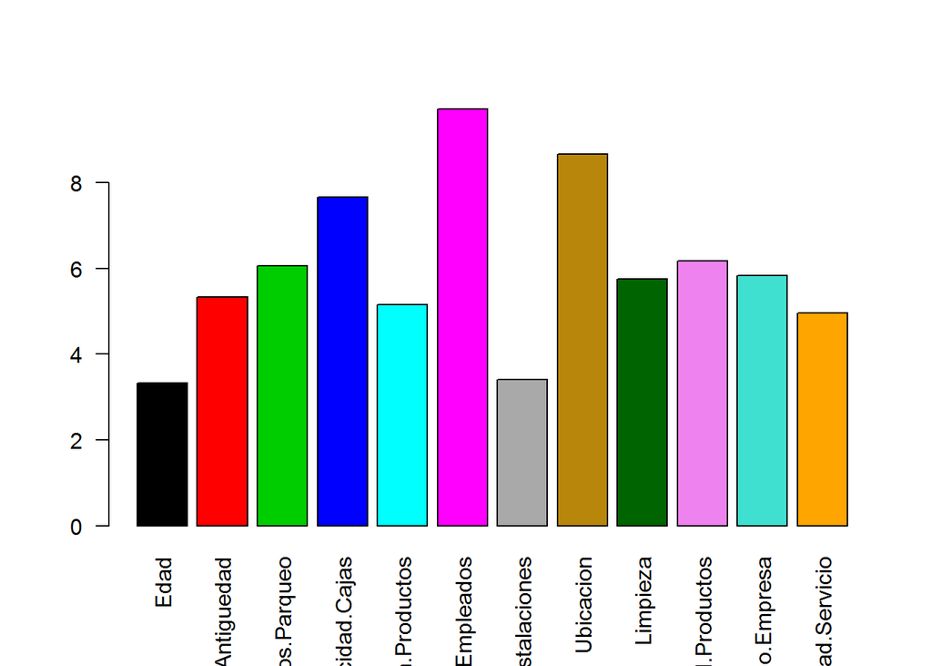

```r
#Tama?o de las clases
barplot(grupos$centers[1,], col = c(1:12), las=2)
```

Group by cluster

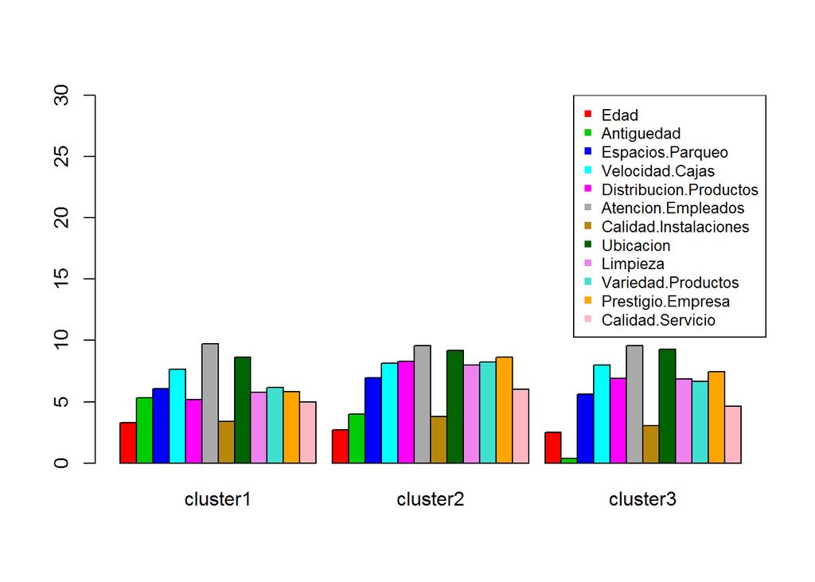

```r
rownames(grupos$centers)<- c("cluster1", "cluster2", "cluster3")
barplot(t(grupos$centers), beside = TRUE, col=c(2:13), ylim = c(0,30))
legend("topright", legend=colnames(datos),
       col=c(2:13), pch=15, cex=0.8)
```

Radarchart

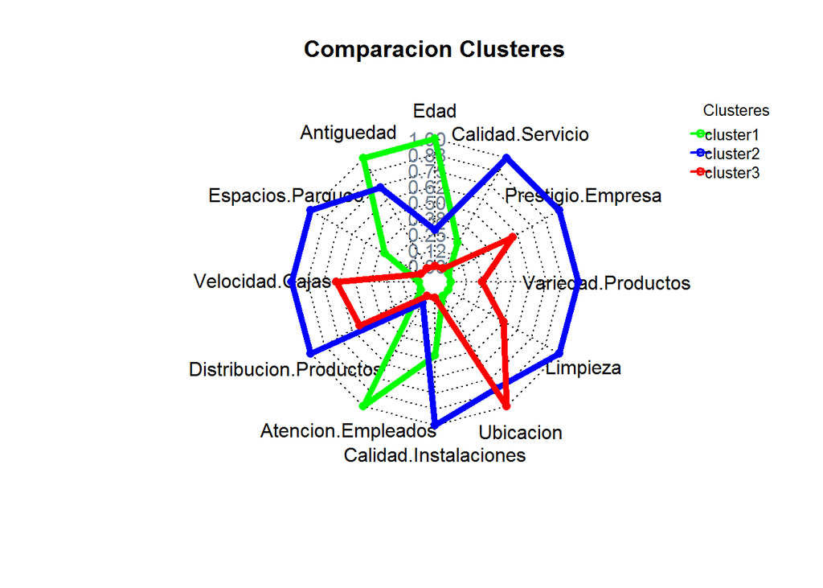

```r
#cargamos paquete para usar radarchat
library(fmsb)
centros <- grupos$centers
centros<- as.data.frame(centros)
maxi <- apply(centros, 2, max)
mini <- apply(centros, 2, min)
centros <- rbind(mini, centros)
centros <- rbind(maxi, centros)

radarchart(centros, maxmin = TRUE, axistype = 4, axislabcol = "slategray4",  centerzero = FALSE, seg=8, cglcol = "gray4", pcol=c("green","blue", "red"), plty = 1, plwd = 5, title="Comparacion Clusteres")
legenda <- legend("topright", legend= c("cluster1", "cluster2", "cluster3"), seg.len=-1.4, title = "Clusteres", pch = 21, bty= "n", lwd = 2, y.intersp = 1, horiz = FALSE, col = c("green","blue", "red"),cex=0.8 )
```

### The k-mean algorithm has as default that every time you run has a different result, in addition we must tell you the number of iterations

# Strong ways to achieve better solutions in kmedias

example Customer support, #### trick nstart= 200 and find the best solution

```r
suppressMessages(library(FactoMineR))
datos <- read.table("C:/Users/Usuario/Desktop/promidat/calibracion_y_seleccion/1/EjemploClientes.csv", header = TRUE, sep = ";", dec = ",",  row.names=1)

#Escalamos los datos de Edad
datos$Edad<- datos$Edad/10
```

K-means, nstart= 200

```r
#agrupamos por el metodo kmeans
grupos<- kmeans(datos, 3, iter.max = 300, nstart = 200)
grupos
```

```
## K-means clustering with 3 clusters of sizes 13, 13, 11
##
## Cluster means:
##       Edad Antiguedad Espacios.Parqueo Velocidad.Cajas
## 1 3.169231   2.769231         5.400000        7.461538
## 2 2.392308   1.307692         6.492308        8.230769
## 3 3.118182   6.181818         6.527273        8.018182
##   Distribucion.Productos Atencion.Empleados Calidad.Instalaciones
## 1               4.476923           9.692308              2.084615
## 2               8.261538           9.669231              4.284615
## 3               6.927273           9.554545              3.845455
##   Ubicacion Limpieza Variedad.Productos Prestigio.Empresa Calidad.Servicio
## 1  9.200000 5.646154           5.723077          5.261538         5.069231
## 2  9.215385 7.615385           7.676923          8.430769         5.423077
## 3  8.509091 6.818182           7.200000          7.618182         4.781818
##
## Clustering vector:
##     Ariana    Guiselle   Francisco    Griselda     Damaris      Johana
##           2           2           3           1           1           1
##     Bernal      Freddy   Estafania       Laura     Arnoldo     Beatriz
##           2           3           1           2           3           3
##     Rebeca       Sofia      Ingrid       Rocio       Karen        Luis
##           2           3           3           1           3           2
##      Pedro      Lorena       Elena      Julian     Natalie     Shirley
##           2           1           3           1           1           1
##     Andres   Alejandro       Grace       Nuria        Flor     Roberto
##           1           3           1           2           2           3
##     Victor      Arturo     Maritza       Diana        Juan   Guillermo
##           2           3           2           1           1           2
##     Silvia
##           2
##
## Within cluster sum of squares by cluster:
## [1] 332.6892 181.1985 191.2055
##  (between_SS / total_SS =  37.6 %)
##
## Available components:
##
## [1] "cluster"      "centers"      "totss"        "withinss"
## [5] "tot.withinss" "betweenss"    "size"         "iter"
## [9] "ifault"
```

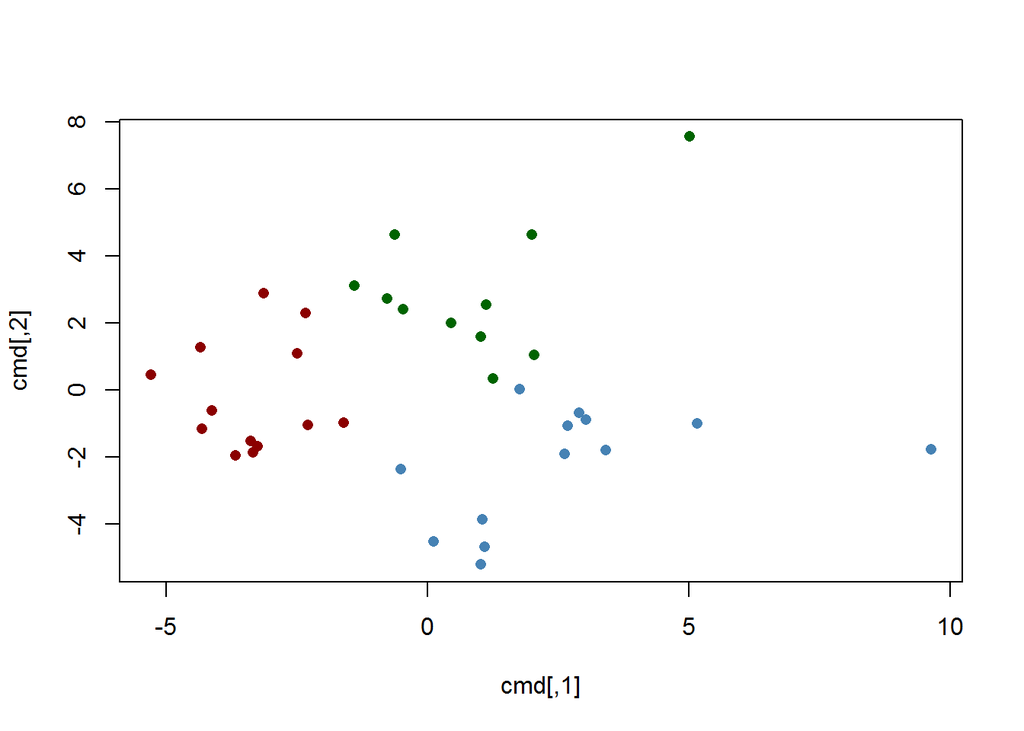

```r
# distance matrix
datos_dist <- dist(datos)

# Multidimensional scaling
cmd <- cmdscale(datos_dist)

# plot MDS, with colors by groups from kmeans
groups <- levels(factor(grupos$cluster))
plot(cmd, type = "n")
cols <- c("steelblue", "darkred", "darkgreen")
for(i in seq_along(groups)){
  points(cmd[factor(grupos$cluster) == groups[i], ], col = cols[i], pch = 16)
}
```

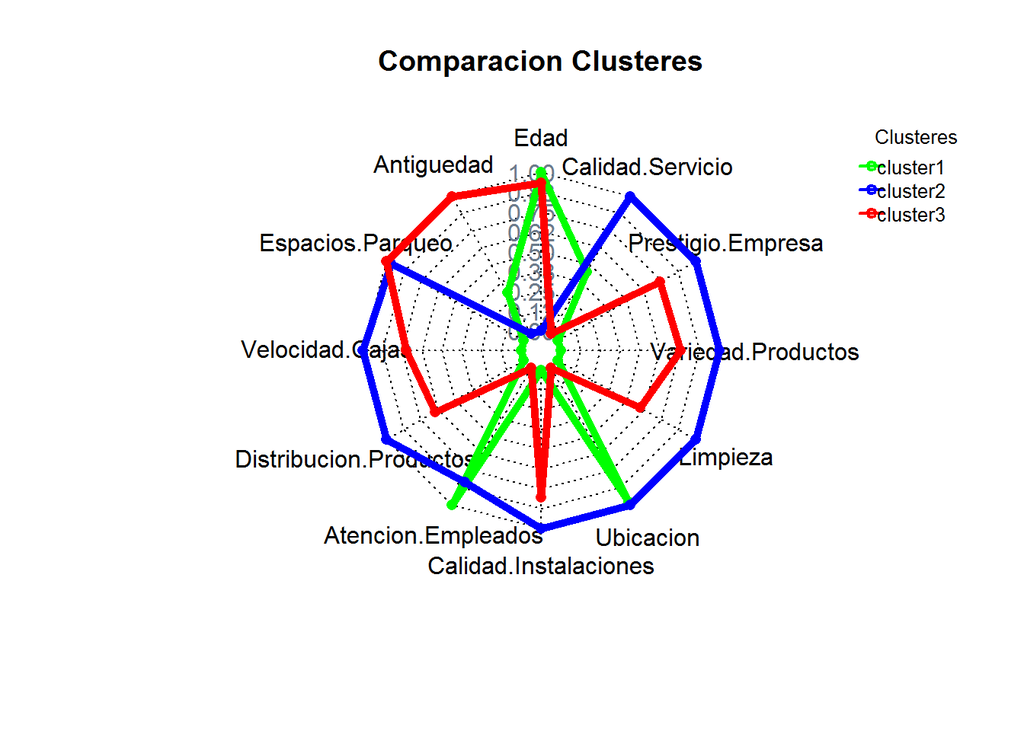

```r
#cargamos paquete para usar radarchat
library(fmsb)
centros <- grupos$centers
centros<- as.data.frame(centros)
maxi <- apply(centros, 2, max)
mini <- apply(centros, 2, min)
centros <- rbind(mini, centros)
centros <- rbind(maxi, centros)

radarchart(centros, maxmin = TRUE, axistype = 4, axislabcol = "slategray4",  centerzero = FALSE, seg=8, cglcol = "gray4", pcol=c("green","blue", "red"), plty = 1, plwd = 5, title="Comparacion Clusteres")
legenda <- legend("topright", legend= c("cluster1", "cluster2", "cluster3"), seg.len=-1.4, title = "Clusteres", pch = 21, bty= "n", lwd = 2, y.intersp = 1, horiz = FALSE, col = c("green","blue", "red"),cex=0.8 )
```

save the data on a .csv file

```r
 ndatos <- cbind(datos, grupos=grupos$cluster)
write.csv(ndatos, "ndatos.csv")
```

## Q: How many clusters should be made ??

### A: It is chosen by the jambu elbow

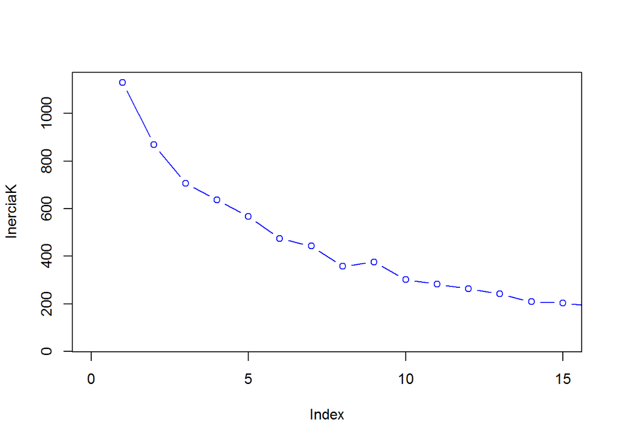

```r
InerciaK = rep(0, 30)

for (k in 1:30) {
    grupos = kmeans(datos, k)
    InerciaK[k] = grupos$tot.withinss

}
plot(InerciaK, col = "blue", type = "b", xlim =c(0,15))
```

# Clustering with qualitative variables and variable mix?

## Kmean or hclust does not work Daysi should be used

Example

```r
library(cluster)

datos <- read.table("C:/Users/Usuario/Desktop/promidat/calibracion_y_seleccion/1/SAheart.csv", header = TRUE, sep = ",", dec = ".", row.names = 1)

head(datos)
```

```
##   sbp tobacco  ldl adiposity famhist typea obesity alcohol age chd
## 1 160   12.00 5.73     23.11 Present    49   25.30   97.20  52  Si
## 2 144    0.01 4.41     28.61  Absent    55   28.87    2.06  63  Si
## 3 118    0.08 3.48     32.28 Present    52   29.14    3.81  46  No
## 4 170    7.50 6.41     38.03 Present    51   31.99   24.26  58  Si
## 5 134   13.60 3.50     27.78 Present    60   25.99   57.34  49  Si
## 6 132    6.20 6.47     36.21 Present    62   30.77   14.14  45  No
```

```r
dim(datos)
```

```
## [1] 462  10
```

Build the Daisy

```r
d<-daisy(datos, metric = "euclidean")
```

and then clusteting and plotting

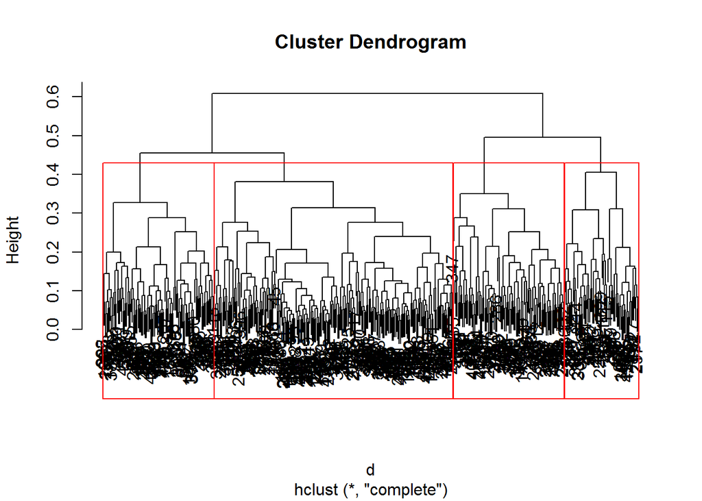

```r
clus<- hclust(d, method = "complete")
plot(clus)
rect.hclust(clus, k=4, border = "red")
```